# WST Pop Model: von Bertalanffy Growth Model (VBGM)

### Background

Most important, I want to understand how S. Blackburn (Univ. of Idaho; SB) took raw CDFW data, and then created dataframes (or other data types) to ‘feed’ the model. This is an important first-step towards understanding the model. Herein I explore how SB used von Bertalanffy growth models (VBGM) in the model (J. DuBois, 09-Feb-2018; see original SB file `VBGM.txt`).

### Data

SB loads Excel file `BCLA.xlsx`, which contains fork length (fl) and age data fields. SB assigns loaded data to variable `wst`. (I saved this file as `.csv` for convenience of loading.)

```r
wst <- read.csv(file = "blackburn_code/BCLA.csv", header = TRUE)
summary(wst)
```

```
##       age               fl
##  Min.   : 1.000   Min.   : 12.01
##  1st Qu.: 3.000   1st Qu.: 49.60
##  Median : 5.000   Median : 66.50
##  Mean   : 5.353   Mean   : 70.79
##  3rd Qu.: 7.000   3rd Qu.: 86.53
##  Max.   :29.000   Max.   :212.22
```

Simply, SB plots fork length as a function of age to examine length-at-age.

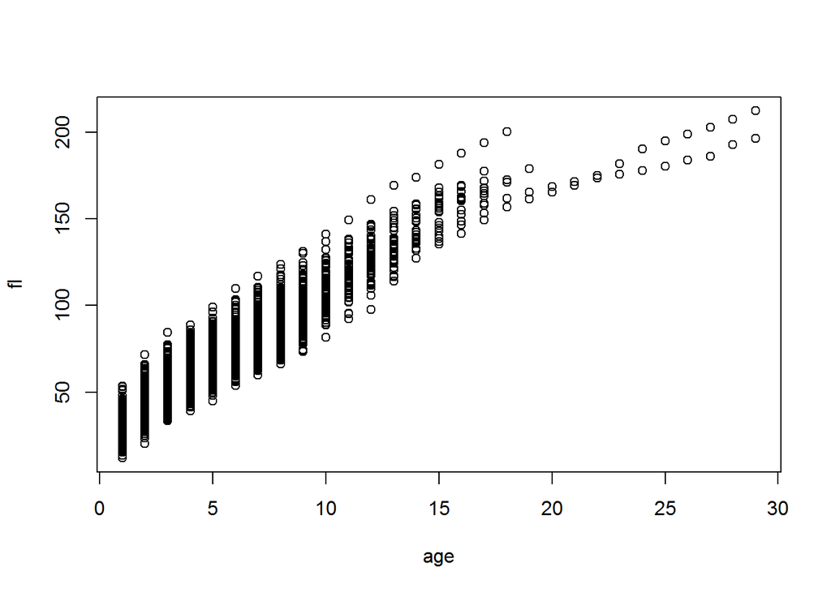

```r
# formatting from SB not included here
plot(fl ~ age, data = wst)
```

### Create VB growth function

Using `vbFuns()` in package `FSA`, SB creates a ‘typical’ von Bertalanffy growth function.

```r
vb <- FSA::vbFuns(param = "Typical", msg = TRUE)
```

```
## You have chosen the 'Typical', 'Traditional', or 'BevertonHolt' parameterization.
##
##   E[L|t] = Linf*(1-exp(-K*(t-t0)))
##
##   where Linf = asymptotic mean length
##            K = exponential rate of approach to Linf
##           t0 = the theoretical age when length = 0 (a modeling artifact)
```

```r
vb
```

```
## function (t, Linf, K = NULL, t0 = NULL)
## {
##     if (length(Linf) == 3) {
##         K <- Linf[[2]]
##         t0 <- Linf[[3]]
##         Linf <- Linf[[1]]
##     }
##     Linf * (1 - exp(-K * (t - t0)))
## }
## <environment: 0x04936e4c>
```

Generate starting values for VBGM using `vbStarts()`.

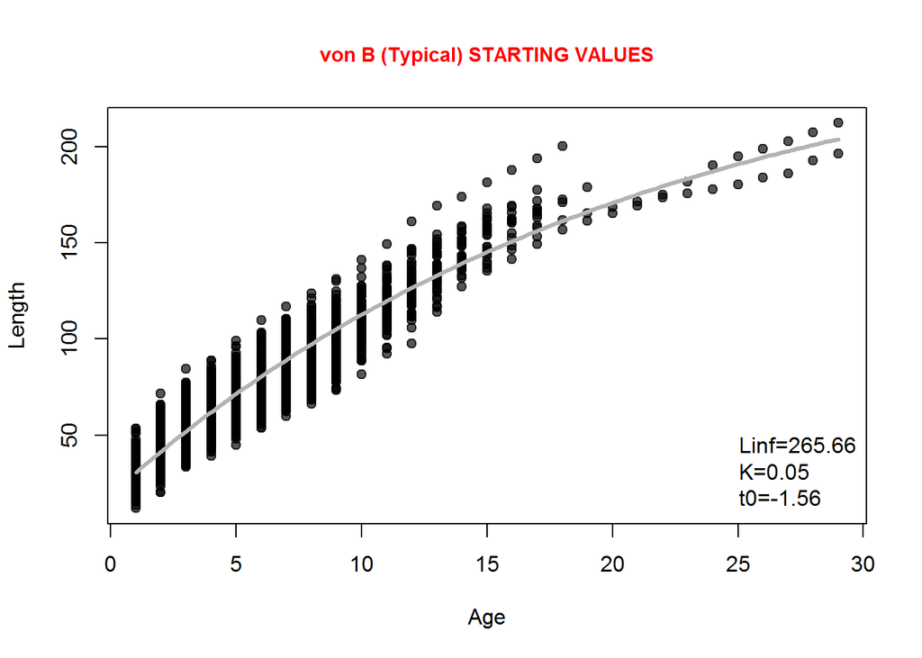

```r
# automatic methods
wst_vbs <- FSA::vbStarts(
  fl ~ age,
  data = wst,
  type = "Typical",
  plot = TRUE
)
```

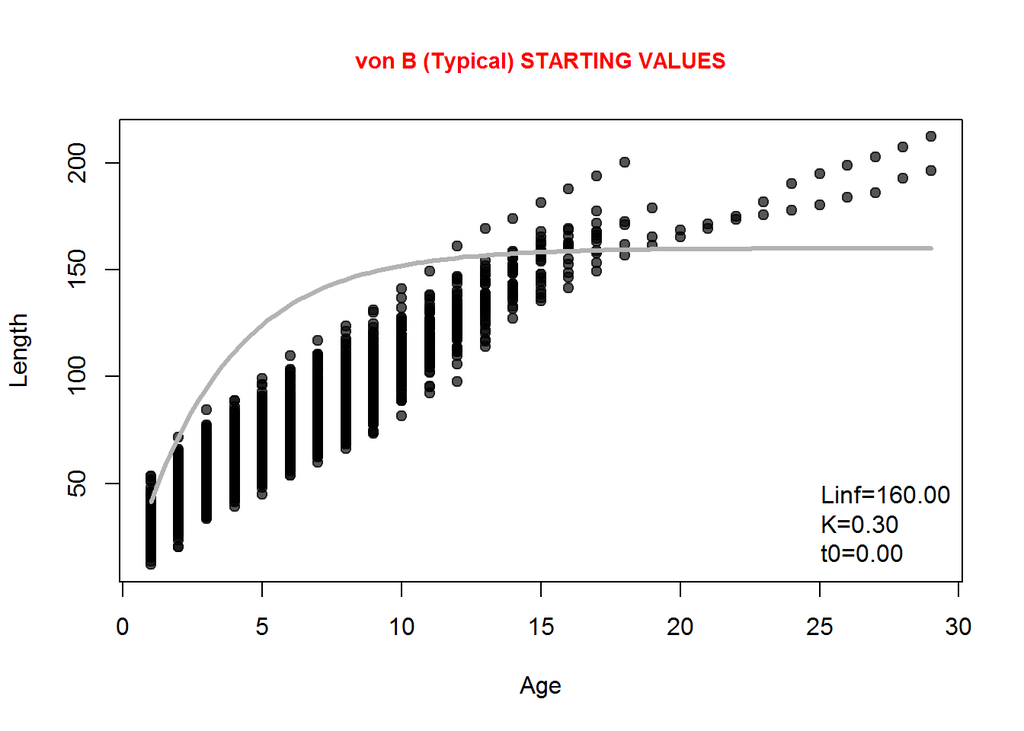

```r
# ... or manual method
wst_vbs <- FSA::vbStarts(
  fl ~ age,
  data = wst,
  type = "Typical",
  plot = TRUE,
  fixed = list(Linf = 160, K = 0.3, t0 = 0)
)
```

### Fit VBGM to data

Using `nls()` and `vb()` fit growth model to data.

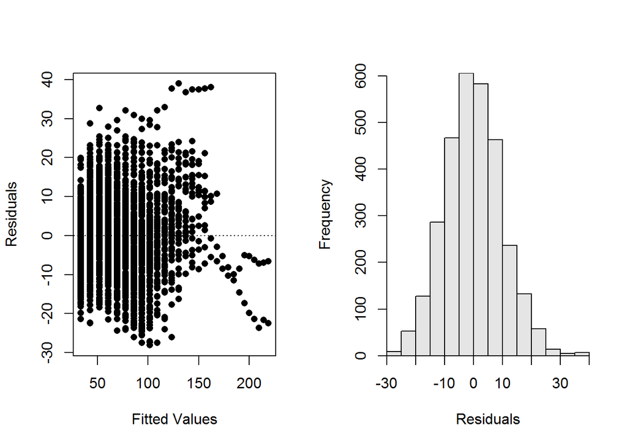

```r
wst_vbf <- stats::nls(
  fl ~ vb(t = age, Linf = Linf, K = K, t0 = t0),
  data = wst,
  start = wst_vbs
)

# look at residual plot
FSA::residPlot(wst_vbf)
```

```r
# extract results
summary(wst_vbf)
```

```
##
## Formula: fl ~ vb(t = age, Linf = Linf, K = K, t0 = t0)
##
## Parameters:
##        Estimate Std. Error t value Pr(>|t|)
## Linf 379.767978  20.194241   18.81   <2e-16 ***
## K      0.027376   0.001903   14.38   <2e-16 ***
## t0    -2.364417   0.082293  -28.73   <2e-16 ***
## ---
## Signif. codes:  0 '***' 0.001 '**' 0.01 '*' 0.05 '.' 0.1 ' ' 1
##
## Residual standard error: 9.979 on 3045 degrees of freedom
##
## Number of iterations to convergence: 12
## Achieved convergence tolerance: 1.608e-06
```

```r
summary(wst_vbf, correlation = TRUE)
```

```
##
## Formula: fl ~ vb(t = age, Linf = Linf, K = K, t0 = t0)
##
## Parameters:
##        Estimate Std. Error t value Pr(>|t|)
## Linf 379.767978  20.194241   18.81   <2e-16 ***
## K      0.027376   0.001903   14.38   <2e-16 ***
## t0    -2.364417   0.082293  -28.73   <2e-16 ***
## ---
## Signif. codes:  0 '***' 0.001 '**' 0.01 '*' 0.05 '.' 0.1 ' ' 1
##
## Residual standard error: 9.979 on 3045 degrees of freedom
##
## Correlation of Parameter Estimates:
##    Linf  K
## K  -1.00
## t0 -0.79  0.84
##
## Number of iterations to convergence: 12
## Achieved convergence tolerance: 1.608e-06
```

```r
wst_vbc <- coef(wst_vbf)
cbind(Est = wst_vbc, confint(wst_vbf))
```

```
##               Est         2.5%       97.5%
## Linf 379.76797766 345.27121975 423.7066015
## K      0.02737645   0.02377521   0.0310577
## t0    -2.36441707  -2.52678593  -2.2093746
```

### Bootstrap estimates of uncertainty

Using `nlsBoot()` from `nlstools` package, get confidence intervals.

```r
wst_vbb <- nlstools::nlsBoot(wst_vbf, niter = 1000)

str(wst_vbb)
```

```
## List of 4
##  $ coefboot: num [1:1000, 1:3] 341 371 375 341 371 ...
##   ..- attr(*, "dimnames")=List of 2
##   .. ..$ : NULL
##   .. ..$ : chr [1:3] "Linf" "K" "t0"
##  $ rse     : num [1:1000] 10.05 10.08 10 10.12 9.94 ...
##  $ bootCI  : num [1:3, 1:3] 379.1231 0.0275 -2.3631 343.7569 0.0238 ...
##   ..- attr(*, "dimnames")=List of 2
##   .. ..$ : chr [1:3] "Linf" "K" "t0"
##   .. ..$ : chr [1:3] "Median" "2.5%" "97.5%"
##  $ estiboot: num [1:3, 1:2] 380.03674 0.02748 -2.3614 20.457 0.00191 ...
##   ..- attr(*, "dimnames")=List of 2
##   .. ..$ : chr [1:3] "Linf" "K" "t0"
##   .. ..$ : chr [1:2] "Estimate" "Std. error"
##  - attr(*, "class")= chr "nlsBoot"
```

```r
FSA::headtail(wst_vbb$coefboot)
```

```
##             Linf          K        t0
## [1,]    341.1785 0.03131003 -2.304651
## [2,]    370.9143 0.02875439 -2.236390
## [3,]    374.7984 0.02762138 -2.416058
##  [998,] 399.2299 0.02577588 -2.409538
##  [999,] 381.3314 0.02756627 -2.287875
## [1000,] 391.9025 0.02622930 -2.452512
```

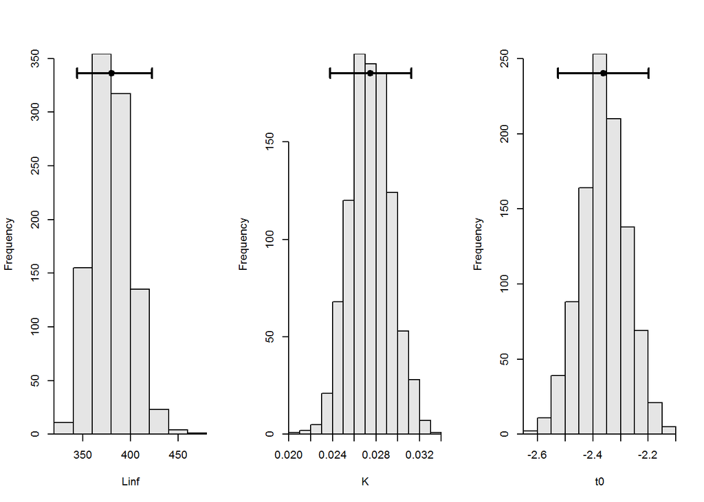

```
##               EST      95% LCI      95% UCI
## Linf 379.76797766 343.75692902 422.77592216
## K      0.02737645   0.02377053   0.03125847
## t0    -2.36441707  -2.52517528  -2.19924946
```

```r
cbind(EST = wst_vbc, confint(wst_vbb, plot = TRUE, rows = 1, cols = 3))
```

#### Predictions

```r
ageX <- 9
predict(wst_vbf, newdata = data.frame(age = ageX))
```

```
## [1] 101.5394
```

```r
wst_vbbp <- apply(wst_vbb$coefboot, MARGIN = 1, FUN = vb, t = ageX)

c(
  pred = predict(wst_vbf, data.frame(age = ageX)),
  quantile(wst_vbbp, probs = c(0.025, 0.975))
)
```

```
##     pred     2.5%    97.5%
## 101.5394 100.9694 102.1110
```

not quite sure what’s going on in this section lines 74:86 but I think SB is adding some CIs to the predictions.

SB is plotting fl ~ age and then adds predicted curve (I think)

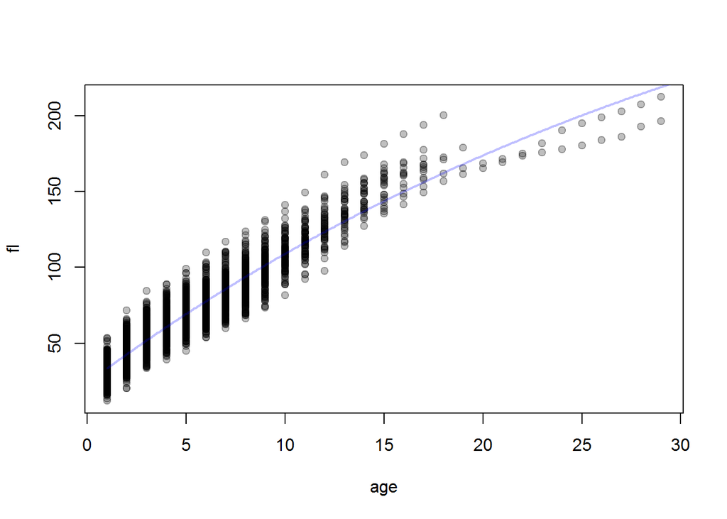

```r
clrs <- FSA::col2rgbt(col = c("black", "blue"), transp = 5/20)

# plot fl ~ age with curve added
plot(
  formula = fl ~ age,
  data = wst,
  pch = 19,
  col = clrs[1]
)
curve(
  vb(t = x, wst_vbc),
  from = 1, to = 30, n = 500,
  lwd = 2,
  col = clrs[2],
  add = TRUE
)
```

```r
# predict length from ages 1 to 50 years
nd <- c(1:50)
predict(wst_vbf, data.frame(age = nd))
```

```
##  [1]  33.41629  42.76956  51.87024  60.72515  69.34094  77.72406  85.88079
##  [8]  93.81724 101.53937 109.05297 116.36366 123.47692 130.39809 137.13235
## [15] 143.68475 150.06021 156.26349 162.29925 168.17202 173.88619 179.44605
## [22] 184.85577 190.11940 195.24088 200.22405 205.07266 209.79032 214.38059
## [29] 218.84689 223.19258 227.42092 231.53507 235.53812 239.43306 243.22282
## [36] 246.91024 250.49807 253.98902 257.38570 260.69064 263.90634 267.03520
## [43] 270.07956 273.04171 275.92386 278.72818 281.45677 284.11168 286.69489
## [50] 289.20834
```

```r
# plot(x = nd, y = predict(wst_vbf, data.frame(age = nd)))
```

### Questions

1. From where did the data in `BCLA.xlsx` come?  
   *374 fish from CDFW plus back calculated, used to back calculate young and old fish*
2. Parameters from this VBGM are used in the exploitation rate ($\mu$) estimation, correct? If so, which final `Linf`, `K`, and `t0` were used?  
   *yes, correct, Linf = 380, k = 0.027, t0 = -2.3*
3. In the manual method, were `Linf = 160`, `K = 0.3`, `t0 = 0` exploratory? Or did these values come from literature or an output? *just exploratory*

Below is me noodling…

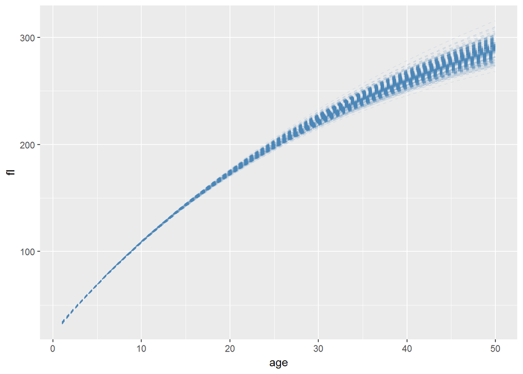

```r
library(ggplot2)

# me noodling 14-Feb-2018
test <- lapply(1:1000, FUN = function(i) {
  len <- vb(
    t = 1:50,
    Linf = wst_vbb$coefboot[i, "Linf"],
    K = wst_vbb$coefboot[i, "K"],
    t0 = wst_vbb$coefboot[i, "t0"]
  )

  # output
  data.frame(
    age = 1:50,
    fl = len,
    group = as.character(i)
  )
})

ggplot(
  data = do.call(what = rbind, args = test),
  mapping = aes(x = age, y = fl, group = group)
) +
  geom_line(alpha = 1/10, linetype = 2, colour = "steelblue")
```

return to top

ran: 2018-02-28 13:26:53  
CDFW, Sportfish unit